# Homework 2

Jessica Temporal 7547611

November 10, 2016

## 1. Read the provided text file into R, making sure to account for headers. This is a truncated cDNA array expression file that has only the Cy5 and Cy3 foreground and background values for 5 separate arrays. The numbers in the suffix of the names are time points (though not necessary for our purposes). (2.5 pts)

## 2. Load the sma library and the MouseArray data file (with data()). (2.5 pts)

## 3. Using list commands, turn the five_arrays matrix file into the list object that is similar to the mouse.data example. See hints below. (10 pts)

## 4. Now create a plot of both un-normalized and lowess normalized data for chip #5 (image.id argument) using the plot.mva function. Make sure to use a par command to put both plots on the same page. Title both plots. For the layout argument in plot.mva(), use the mouse.setup file. (15 pts)

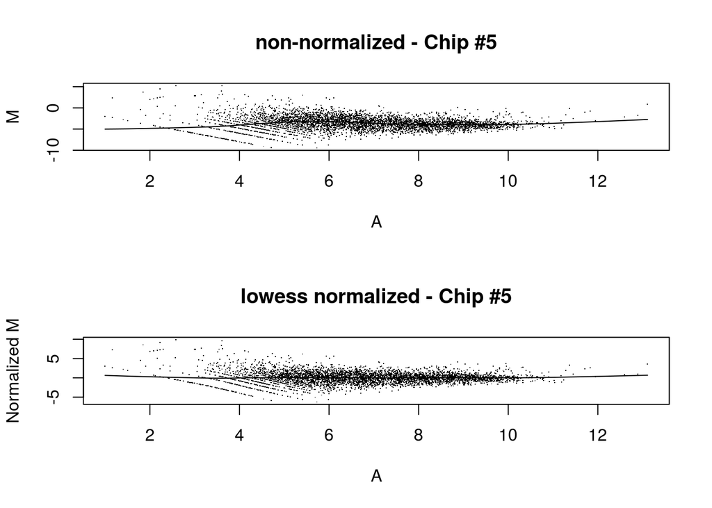